# Applications of Inference Frameworks: Difference of Means

## Horned lizard predation

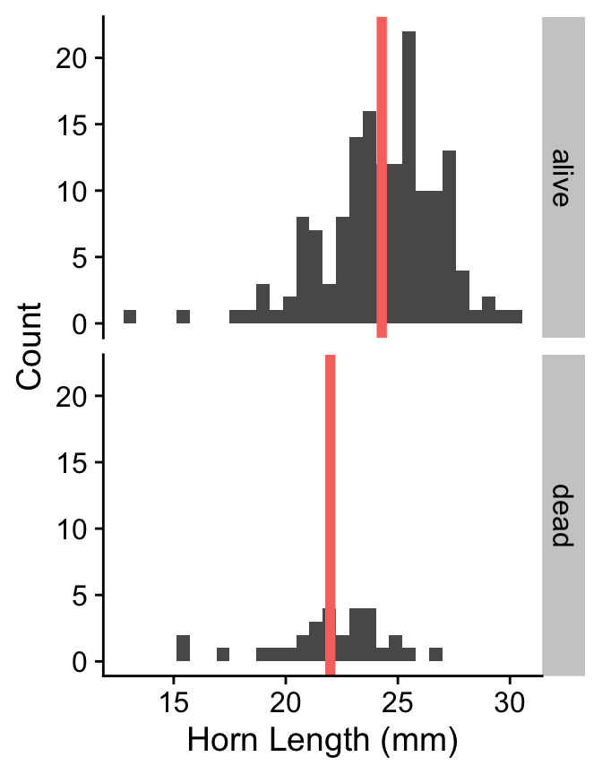

Horn length in live horned lizards: 24.28 mm

Horn length in dead horned lizards: 21.99 mm

Difference: 2.29

Are the means different?

[figure not shown]

## Frameworks for inference

1. Analytical
2. Maximum likelihood
3. Resampling
4. Bayesian

## ML Comparison

*Model 1*: Data drawn from one distribution

*Model 2*: Data drawn from distributions with 2 different means

Compare the models with a likelihood ratio (Bayes Factor):

\[BF = \frac{\mathcal{L}[Model~2]}{\mathcal{L}[Model~1]}\]

## Data drawn from one distribution

Single sample variance:

\[s^2 = \frac{1}{n - 1}\left(\sum^{n_1}_{i=1} \left(y_i - \bar{y}\right)^2\right)\]

Shared variance:

\[\hat{\sigma}^2_1 = \frac{1}{n_1 + n_2}\left(\sum^{n_1}_{i=1}\left(y_{1i} - \bar{\bar{y}}\right)^2 + \sum^{n_2}_{i=1} \left(y_{2i} - \bar{\bar{y}}\right)^2 \right)\]

where \(\bar{\bar{y}}\) is the grand mean.

## Data drawn from one distribution

Likelihood of the \(y\)s being drawn from the same distribution:

\[\mathcal{L}\left(\hat{\mu}, \hat{\sigma}^2_1|y\right) = \frac{1}{\left(2\pi \hat{\sigma}^2_1\right)^\left(\frac{n_1 + n_2}{2}\right)}e^{\left(-\frac{n_1 + n_2}{2}\right)}\]

## Data drawn from distributions with 2 different means

Assume equal variances but different means.

\[\hat{\sigma}^2_2 = \frac{1}{n_1 + n_2}\left(\sum^{n_1}_{i=1}\left(y_{1i} - \bar{y}_1\right)^2 + \sum^{n_2}_{i=1} \left(y_{2i} - \bar{y}_2\right)^2 \right)\]

\[\mathcal{L}\left(\hat{\mu}_1, \hat{\mu}_2, \hat{\sigma}^2_2|y\right) = \frac{1}{\left(2\pi \hat{\sigma}^2_2\right)^\left(\frac{n_1 + n_2}{2}\right)}e^{\left(-\frac{n_1 + n_2}{2}\right)}\]

## ML Comparison

*Model 1*: Data drawn from one distribution

*Model 2*: Data drawn from distributions with 2 different means

Compare the models with a likelihood ratio (Bayes Factor):

\[BF = \frac{\mathcal{L}[Model~2]}{\mathcal{L}[Model~1]} = \frac{\mathcal{L}\left(\hat{\mu}_1, \hat{\mu}_2, \hat{\sigma}^2_2|y\right)}{\mathcal{L}\left(\hat{\mu}, \hat{\sigma}^2_1|y\right)} = \left(\frac{\hat{\sigma}^2_2}{\hat{\sigma}^2_1}\right)^{-\frac{n_1 + n_2}{2}}\]

## Resampled difference of means

```r
set.seed(8734)
reps <- 50000
diffs <- numeric(length = reps)

diffs[1] <- mean(HL$horn_length[HL$group == "alive"]) -
  mean(HL$horn_length[HL$group == "dead"])

for (ii in 2:reps) {
  shuffle <- sample(HL$horn_length)
  diffs[ii] <- mean(shuffle[HL$group == "alive"]) -
    mean(shuffle[HL$group == "dead"])
}
```

## Difference of means

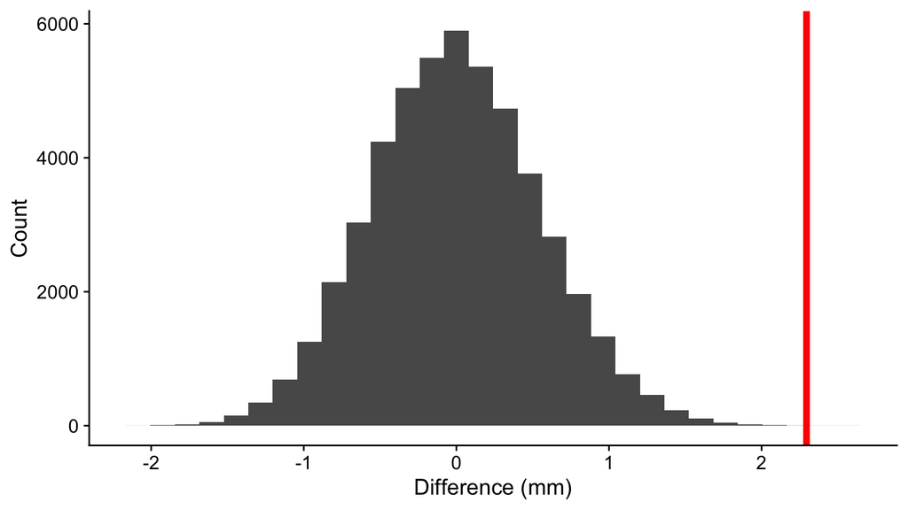

## What proportion of randomized differences are equal to or more extreme than the observed?

```r
p <- sum(diffs[1] <= diffs) / length(diffs)
sprintf("%.5f", p)
```

```
## [1] "0.00006"
```

```r
sprintf("%.5f", 3 / 50000)
```

```
## [1] "0.00006"
```

## Bayesian

Prepare data:

```r
HL <- read_csv("../data/HornedLizards.csv") %>%
  drop_na() %>%
  mutate(group = as.integer(factor(group))) %>%
  as.data.frame()
str(HL)
```

```
## 'data.frame':    184 obs. of  2 variables:
##  $ horn_length: num  25.2 26.9 26.6 25.6 25.7 25.9 27.3 25.1 30.3 25.6 ...
##  $ group      : int  1 1 1 1 1 1 1 1 1 1 ...
##  - attr(*, "spec")=
##   .. cols(
##   ..   horn_length = col_double(),
##   ..   group = col_character()
##   .. )
```

`group` is converted to integers: 1 == alive, 2 == dead.

## Bayesian

```r
mean(HL$horn_length)
```

```
## [1] 23.90707
```

Prior for group means (alive, dead) ~ \(\mathcal{N}(\mu = 25, \sigma = 5)\)

- ~95% of probability lies between 15 and 35
- Estimate posterior distribution of each group simultaneously

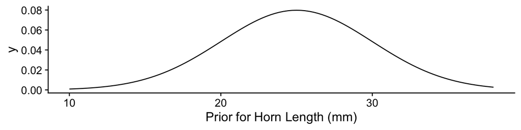

## Bayesian

```r
fm2 <- ulam(
  alist(
    horn_length ~ normal(mu, sigma),
    mu <- a[group],
    a[group] ~ normal(25, 5),
    sigma ~ exponential(0.5)
  ),
  data = HL,
  chains = 4,
  iter = 1e4)
```

## Bayesian

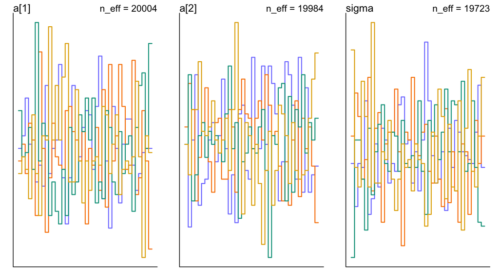

## Bayesian posterior distributions

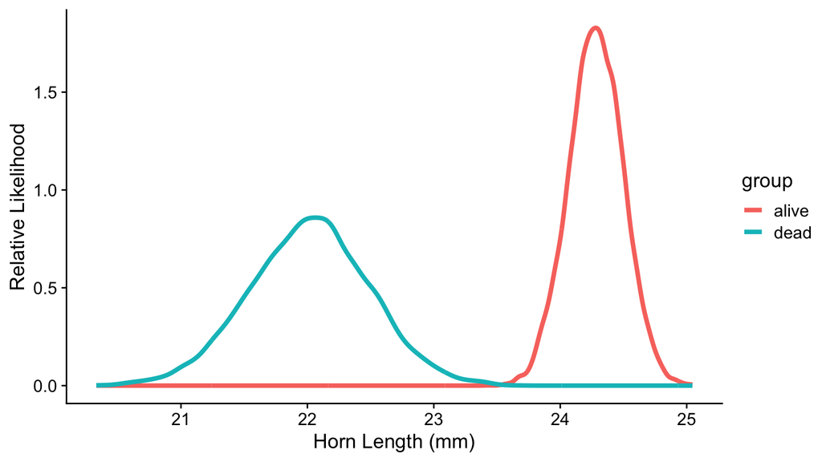

## Bayesian summary

```r
precis(fm2, depth = 2, digits = 4)
```

```
##            mean        sd      5.5%     94.5%    n_eff     Rhat4
## a[1]  24.282334 0.2172137 23.932449 24.628255 20004.25 0.9999335
## a[2]  22.018061 0.4820487 21.248004 22.791661 19983.65 0.9999491
## sigma  2.652681 0.1394267  2.440711  2.884273 19722.54 1.0000356
```

```r
HL %>% group_by(group) %>%
  summarize(horn_mean = mean(horn_length),
            horn_sem = sd(horn_length) / sqrt(length(horn_length)))
```

```
## # A tibble: 2 x 3
##   group horn_mean horn_sem
##   <int>     <dbl>    <dbl>
## 1     1      24.3    0.212
## 2     2      22.0    0.495
```

## Bayesian credible interval

95% credible interval of difference between alive and dead:

[figure not shown]

```r
HPDI(d, prob = 0.95)
```

```
##    |0.95    0.95|
## 1.237601 3.313789
```